# Report exercise 8.5

Elias Köppel

2023-03-13

Importing and reducing data

```r
library(readr)
library(ggplot2)
library(dplyr)
half_hourly_fluxes <- readr::read_csv("C:/Users/elias/OneDrive/Uni/4. Semester/Geo/AGDS I/agds_report_eliaskoeppel/data/report_8_df_for_stepwise_regression.csv")
# remove not-useful data (dates and locations)
half_hourly_fluxes_reduced <- half_hourly_fluxes[3:17]
```

In this first chunk I managed to get all bivariate models and their r-squared values in a for-loop. I also managed to get the AIC of the model with the highest r-squared value and to make a plot with this best explanatory variable.

```r
# Round 1

models <- list()

r_squared <- numeric()



for (i in 1:ncol(half_hourly_fluxes_reduced)){
   if (colnames(half_hourly_fluxes_reduced)[i] != "GPP_NT_VUT_REF") { # it should not take "GPP_NT_VUT_REF as an explainatory variable, because it is the target variable
    models[[i]] <- lm(half_hourly_fluxes_reduced$GPP_NT_VUT_REF ~ (half_hourly_fluxes_reduced[[i]])) #getting linear models for each of the explainatory variables
    r_squared[i] <- summary(models[[i]])$r.squared #getting the r-squared values of the models and putting them into a list
    }
}

var_selected <- which.max(r_squared) # getting the index of the the highest r-squared value for further steps
best_model1 <- models[[which.max(r_squared)]] # extracting the model with the highest r-squared value
AIC_best_model <- extractAIC(best_model1)[2] # getting the AIC of the model with the highests r-squared value

r_max_1 <- r_squared[which.max(r_squared)] # getting the highest r-squared value for visualisation in the end
```

Visualization of the first best explanatory variable

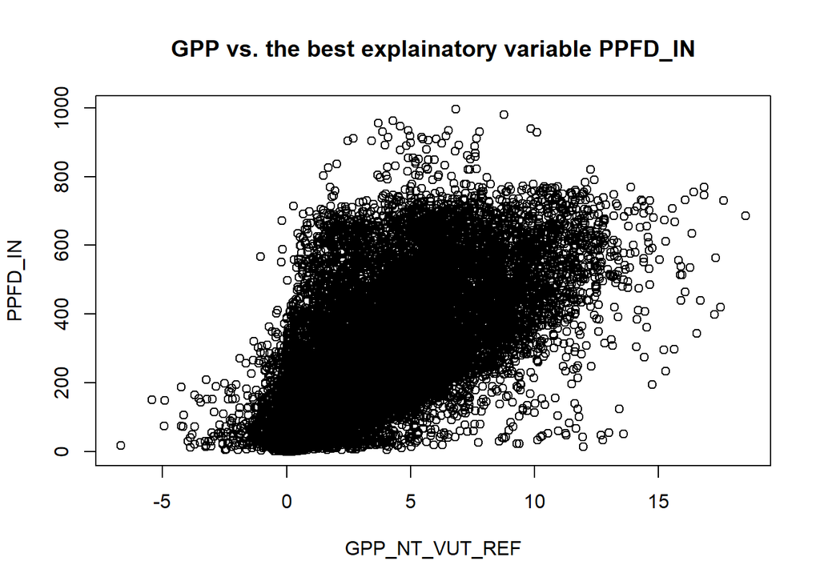

```r
name_var_selected <- names(half_hourly_fluxes_reduced[var_selected]) # to get the name of the best variable. Then I used this variable name to make the following plot:
plot( PPFD_IN ~ GPP_NT_VUT_REF, data = half_hourly_fluxes_reduced, main = "GPP vs. the best explainatory variable PPFD_IN")
```

We see in this plot that there is a clear correlation between the target variable GPP_NT_VUT_REF and the explanatory variable PPFD_IN. GPP_NT_VUT_REF is the amount of chemical energy, typically expressed as carbon biomass, that primary producers create in a given length of time (Wikipedia). PPFD_IN is the incoming Photosynthetic photon flux density. So it absolutely makes sense that there seems to be a connection between these two variables, because light is needed for primary production (–> photosynthesis).

Next I’m going to discuss briefly some visualizations of statistical metrics:

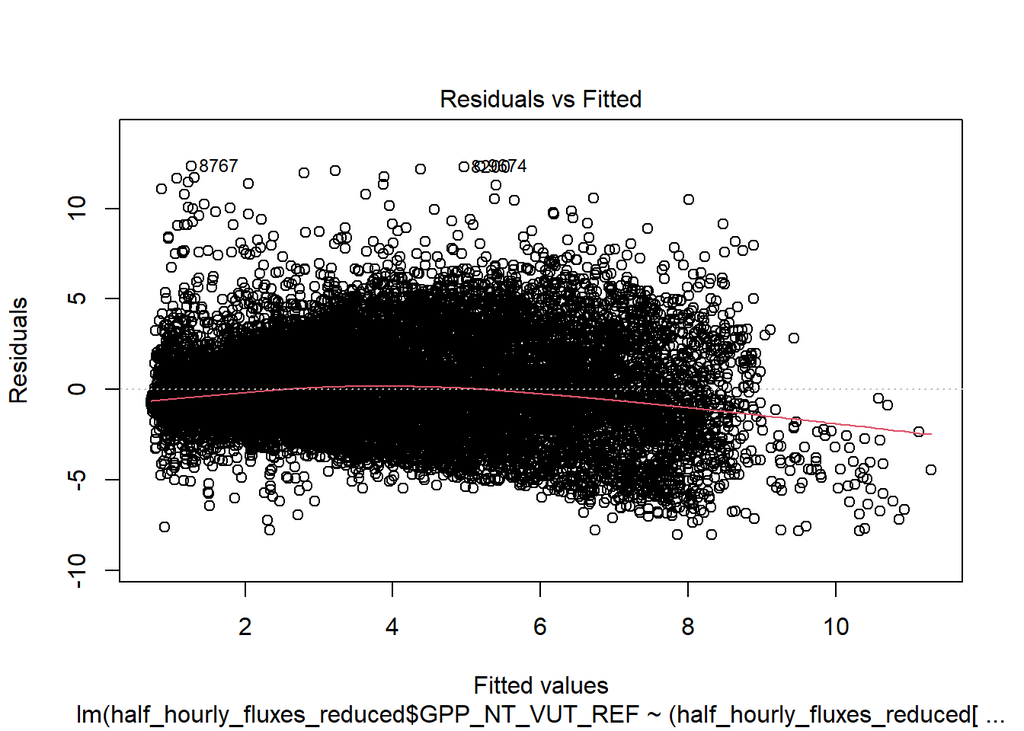

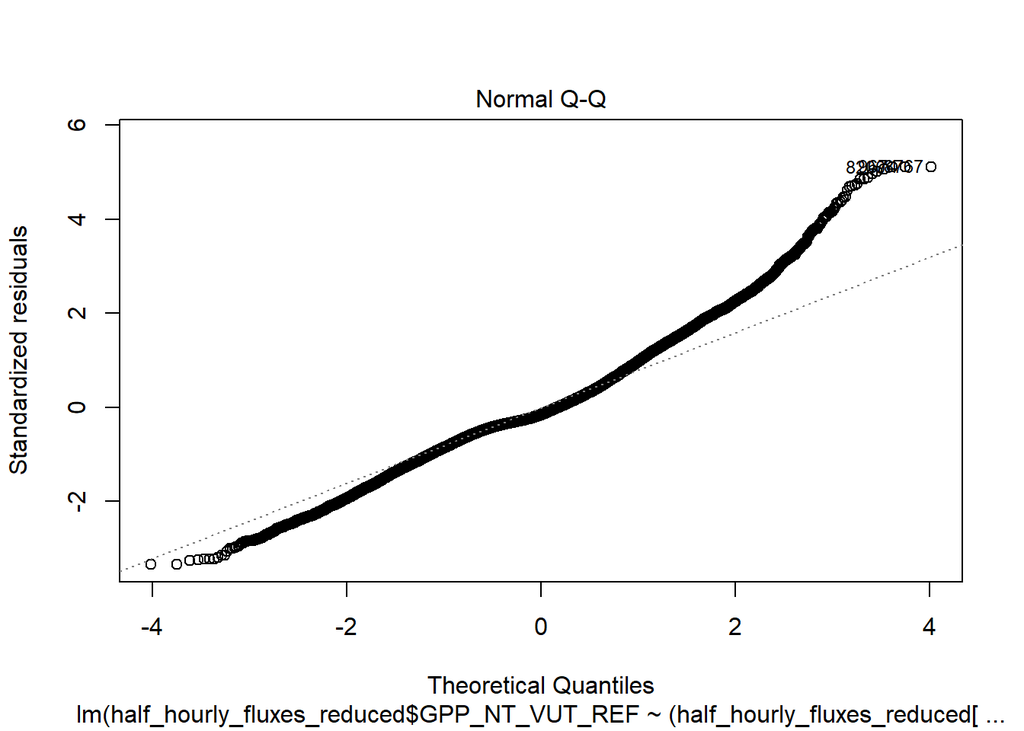

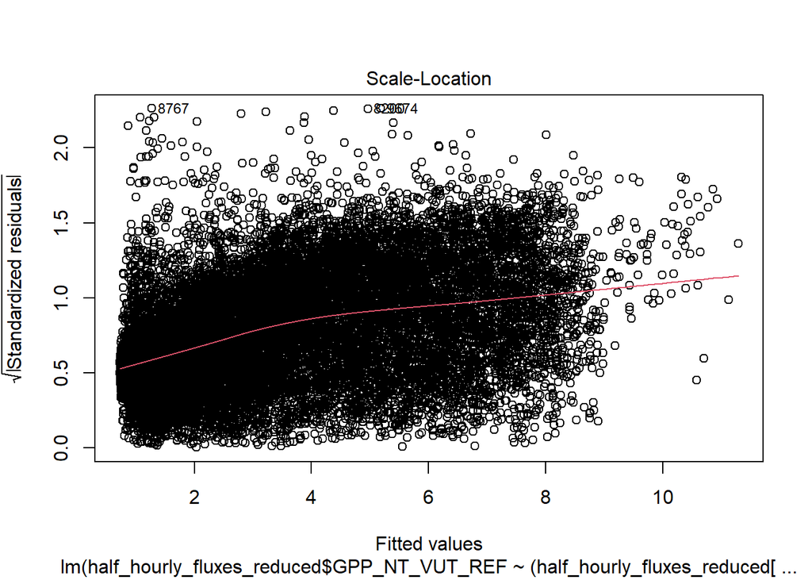

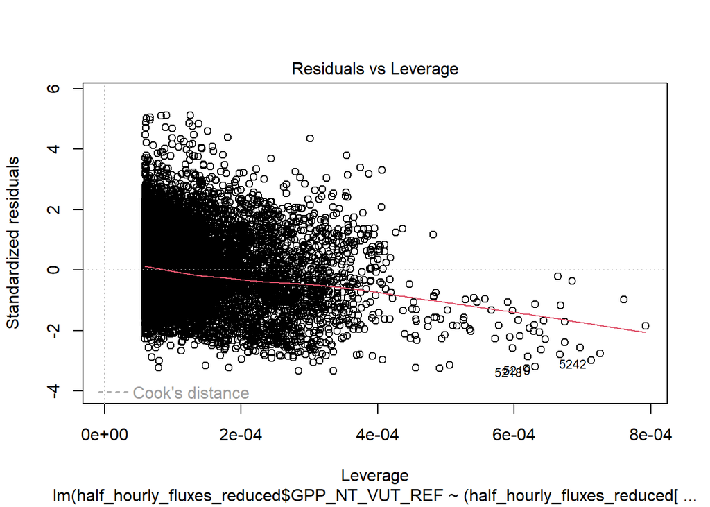

```r
plot(best_model1)
```

First Plot: Residuals vs. Fitted: Here we see that linearity seems to hold reasonably well, as the red line is close to the dashed line. We can also note the as we move to the right on the x-axis, the spread of the residuals seems to be increasing.

Second Plot: Normal Q-Q-Plot: We can see that the data points near the tails don’t fall along the straight line. So it seems that the dataset likely does not follow a normal distribution.

Even after many hours of trying to implement the further steps of the step forward regression in form of a loop, I did not manage to do it.

Therefore, I coded two further “rounds” manually, to at least get an impression of how the AIC develops when adding further variables:

Round 2:

```r
models2 <- list()

r_squared2 <- numeric()

for (i in 1:ncol(half_hourly_fluxes_reduced[-(var_selected)])){ #the variable which has been used for the first model ("best_model") is beeing excluded
if (colnames(half_hourly_fluxes_reduced)[i] != "GPP_NT_VUT_REF") {
  models2[[i]] <- lm(half_hourly_fluxes_reduced$GPP_NT_VUT_REF ~ half_hourly_fluxes_reduced[[var_selected]] + half_hourly_fluxes_reduced[[i]]) # here I get all the models with two explainatory variables
  r_squared2[i] <- summary(models2[[i]])$r.squared} #getting the r-squared values
}




var_selected2 <- which.max(r_squared2) # here I get the index of the variable with the highest r-spared values which I could use for the next step



r_max_2 <- r_squared[which.max(r_squared2)]
best_model2 <- models2[[which.max(r_squared2)]]
AIC_best_model2 <- extractAIC(best_model2)[2]
AIC_best_model2
```

```
## [1] 27096.52
```

So we see that through adding another explanatory variable, the AIC was reduced from 29689 to 27096, which is a reduction of ca. 9%.

Round 3:

```r
models3 <- list()

r_squared3 <- numeric()



for (i in 1:ncol(half_hourly_fluxes_reduced[-(c(var_selected, var_selected2))])){ #the variables which have been used for the previous model ("best_model1") is beeing excluded
if (colnames(half_hourly_fluxes_reduced)[i] != "GPP_NT_VUT_REF") {
  models3[[i]] <- lm(half_hourly_fluxes_reduced$GPP_NT_VUT_REF ~ half_hourly_fluxes_reduced[[var_selected]] + half_hourly_fluxes_reduced[[var_selected2]]+ half_hourly_fluxes_reduced[[i]]) # here I get all the models with three explainatory variables
  r_squared3[i] <- summary(models3[[i]])$r.squared} #getting the r-squared values
}




var_selected3 <- which.max(r_squared3) # here I get the index of the variable with the highest r-spared values which I could use for the next step



r_max_3 <- r_squared[which.max(r_squared3)]
best_model3 <- models3[[which.max(r_squared3)]]
AIC_best_model3 <- extractAIC(best_model3)[2]
AIC_best_model3
```

```
## [1] 25420.8
```

By adding a third explanatory variable, the AIC was reduced by 6%. Although this is still a clear reduction, it is already somewhat smaller than in the previous step. This may be related to the fact that AIC takes into account the use of more variables. It would be interesting to observe the development of the AIC over further steps of the step forward regression - however, this becomes very confusing without a loop and therefore I end my analysis at this stage. But I assume that the reduction of the AIC decreases in each step - until it finally even increases and then the addition of more variables is being stopped.